# Graft Failure as Censored

Fan Wu

2016-11-25

## Data Manipulation

We use the ESRD patients listed for kidney transplantation in 2006 from 40 U.S. states. The *time origin* is set at the ESRD onset, which is the *date of the first renal replacement therapy*, either regulatory dialysis or kidney transplantation. The patients with pre-emptive transplantations are also included. We restriced to the patients who started their first renal replacement therapy after Jan. 1, 1995 The follow-up was until Dec. 4, 2015. The event of interest is *patient death*. We exclude those patients

- first start with dialysis but have no dialysis modality recorded (7%)
- first start with dialysis but have unknown dialysis modality (3%)
- first start with dialysis and change the modality of dialysis before TX (3%)
- first start with dialysis but have no dialysis date recorded (15%)

We allow the renal replacement therapy of a patient change during the follow up, from dialysis to TX after receiving an allograft. If the allograft fails, we censor the patient’s survival time at the time of the graft failure (the date when he/she undergoes re-transplantation or reinitiate dialysis). Thus, the treatment is a **time-dependent** covariate.

We also adjusted for age at ESRD onset (18-40, 40-60, 60+), gender and race.

The number of patients, number of events, and censoring rates for each included states are as follows:

|  | n.Patients | n.Deaths | cens.rate |
| --- | --- | --- | --- |
| CA | 2912 | 840 | 71.2 |
| TX | 1782 | 491 | 72.4 |
| NY | 1597 | 489 | 69.4 |
| PA | 1203 | 430 | 64.3 |
| FL | 1040 | 315 | 69.7 |
| IL | 971 | 336 | 65.4 |
| MI | 783 | 283 | 63.9 |
| OH | 769 | 258 | 66.4 |
| VA | 653 | 259 | 60.3 |
| NC | 549 | 160 | 70.9 |
| TN | 516 | 165 | 68.0 |
| AL | 495 | 217 | 56.2 |
| GA | 483 | 141 | 70.8 |
| MN | 482 | 146 | 69.7 |
| NJ | 476 | 164 | 65.5 |
| AZ | 432 | 117 | 72.9 |
| MA | 432 | 150 | 65.3 |
| MO | 430 | 117 | 72.8 |
| MD | 376 | 121 | 67.8 |
| WI | 347 | 111 | 68.0 |
| LA | 329 | 107 | 67.5 |
| IN | 322 | 98 | 69.6 |
| CO | 284 | 100 | 64.8 |
| WA | 278 | 75 | 73.0 |
| DC | 254 | 72 | 71.7 |
| OR | 209 | 66 | 68.4 |
| KY | 183 | 62 | 66.1 |
| OK | 140 | 55 | 60.7 |
| SC | 140 | 42 | 70.0 |
| AR | 137 | 50 | 63.5 |
| UT | 137 | 30 | 78.1 |
| NE | 136 | 41 | 69.9 |
| CT | 119 | 32 | 73.1 |
| IA | 119 | 41 | 65.5 |
| KS | 103 | 28 | 72.8 |
| NM | 84 | 27 | 67.9 |
| NV | 81 | 24 | 70.4 |
| ME | 69 | 23 | 66.7 |
| ND | 66 | 19 | 71.2 |
| WV | 62 | 29 | 53.2 |

## Estimate of the PD and TX log Hazards

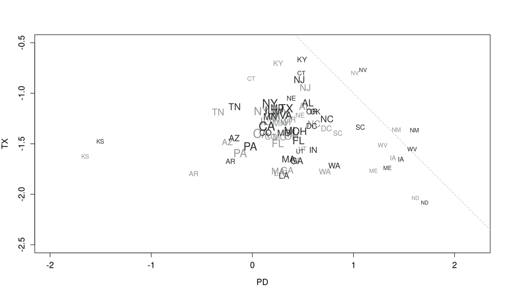

## Estimate of the YOUNG and OLD log Hazards

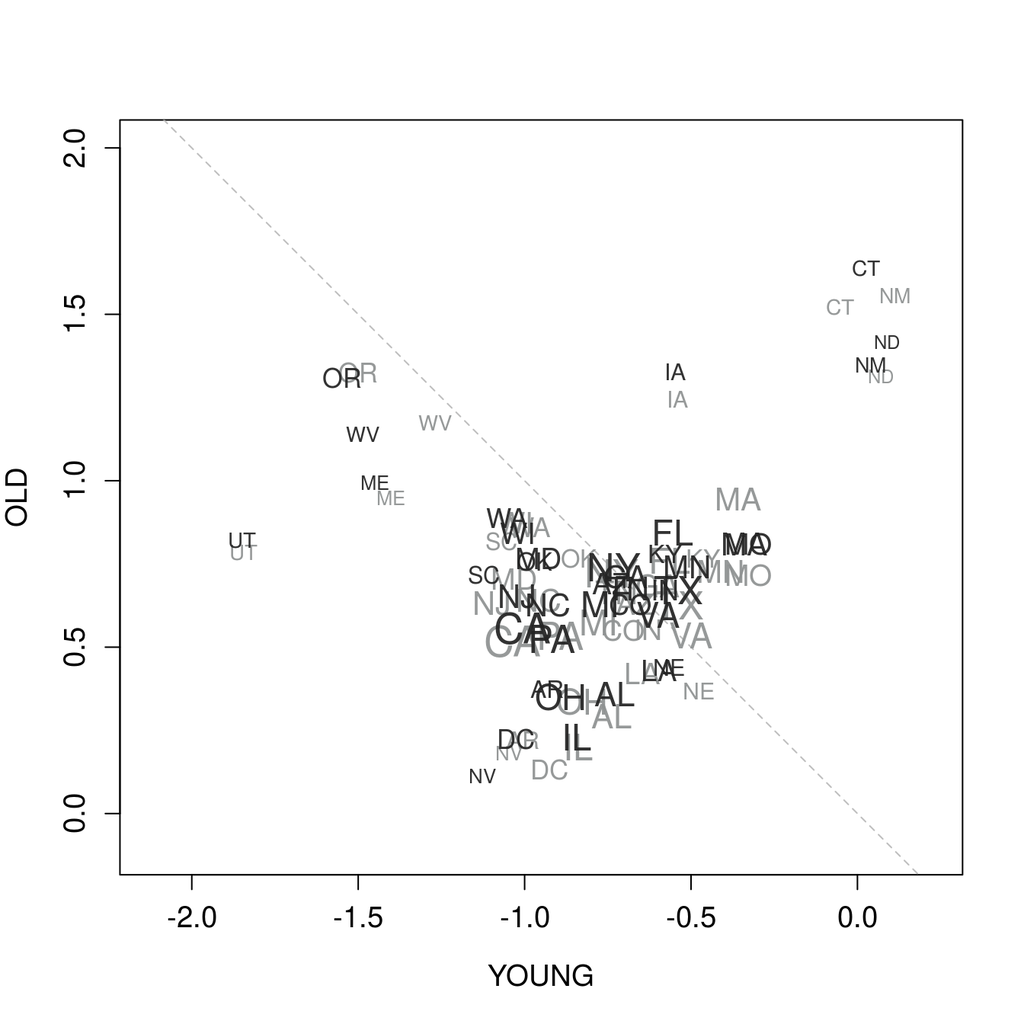

## Compare SEs using Conditional vs PLAC

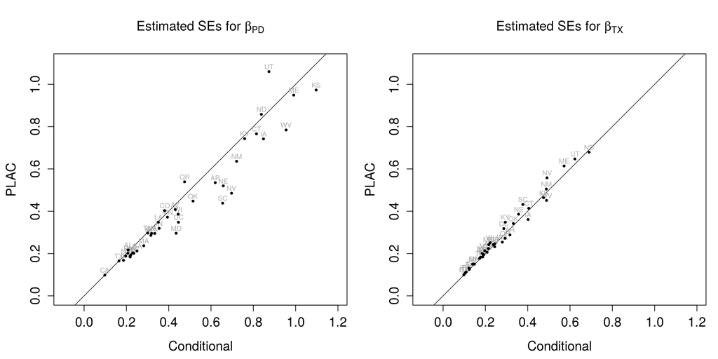

## Compare Ratio of Variances using Conditional vs PLAC

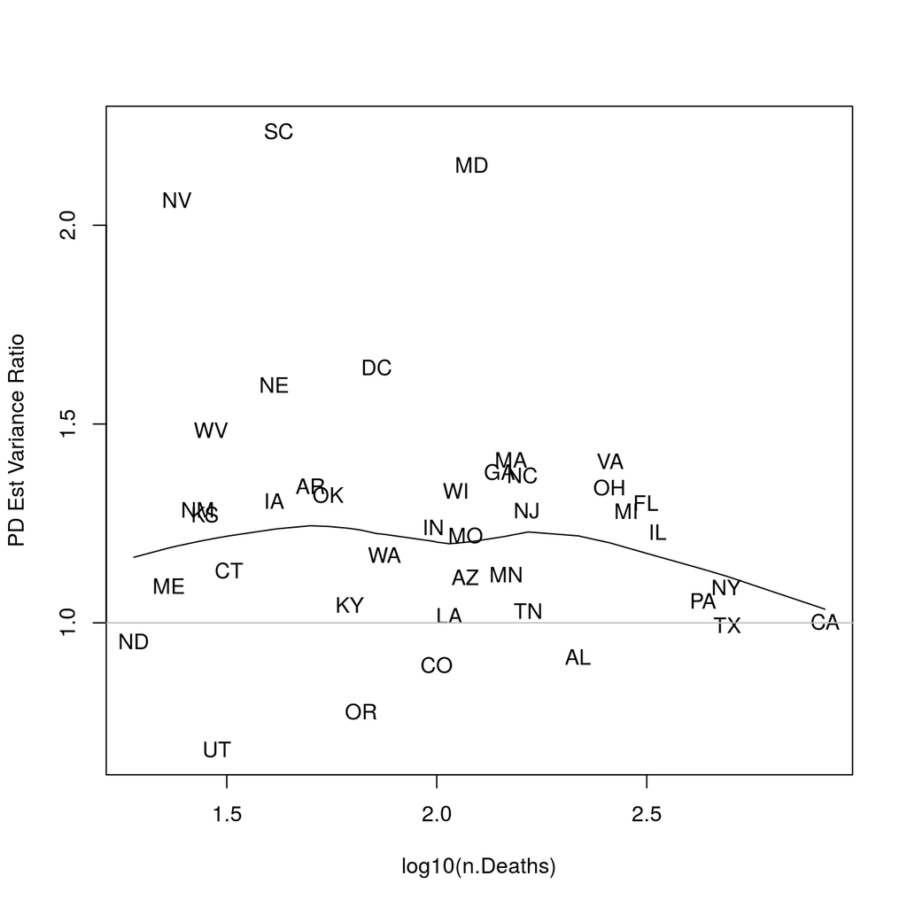

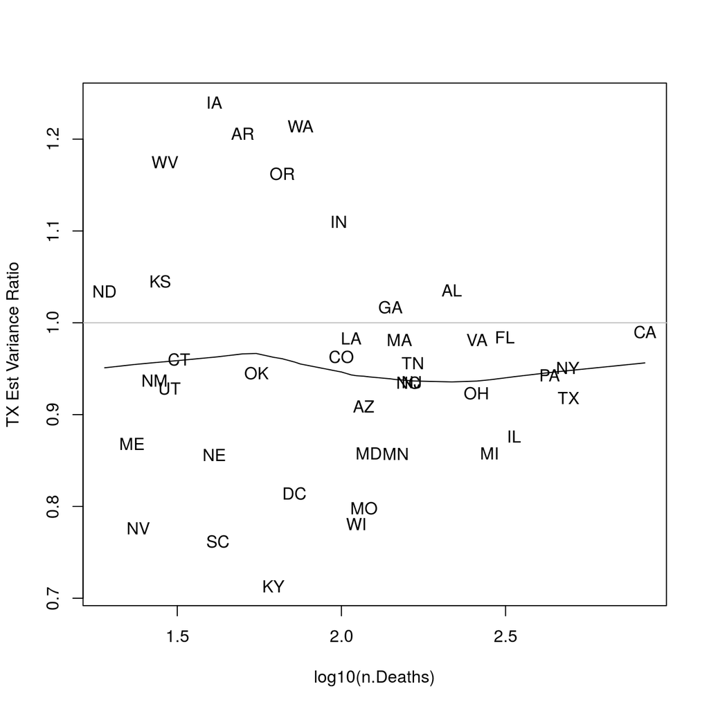

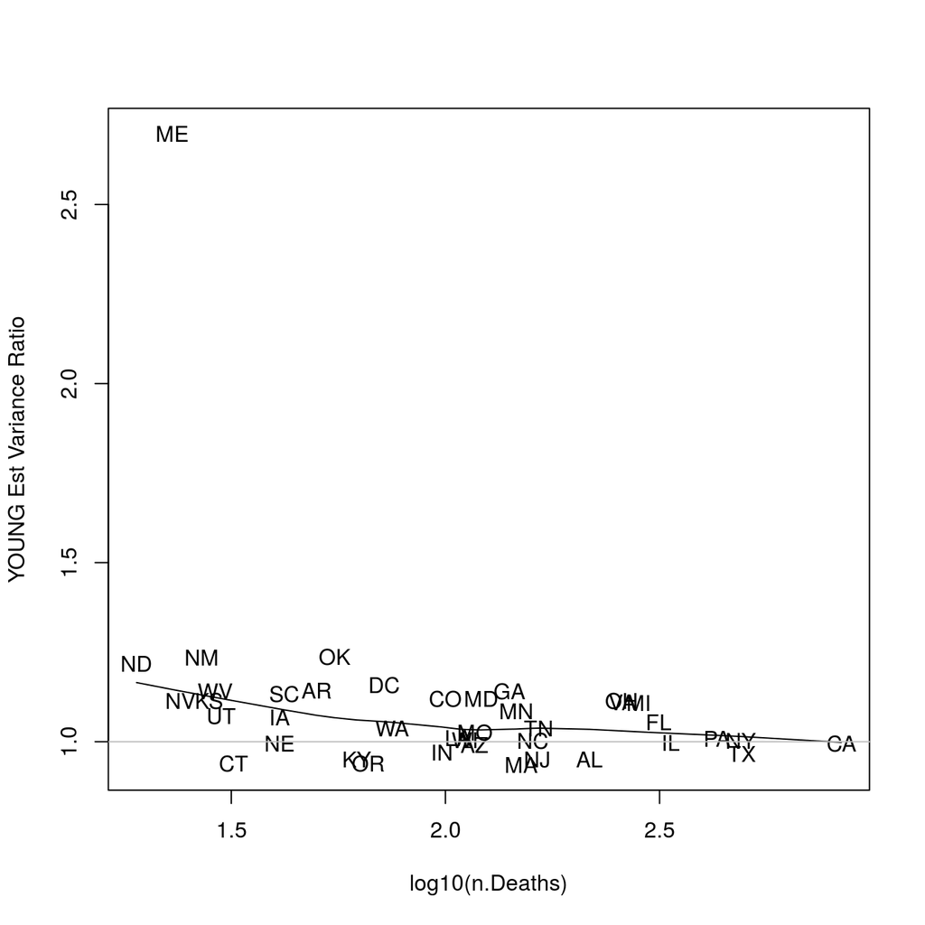

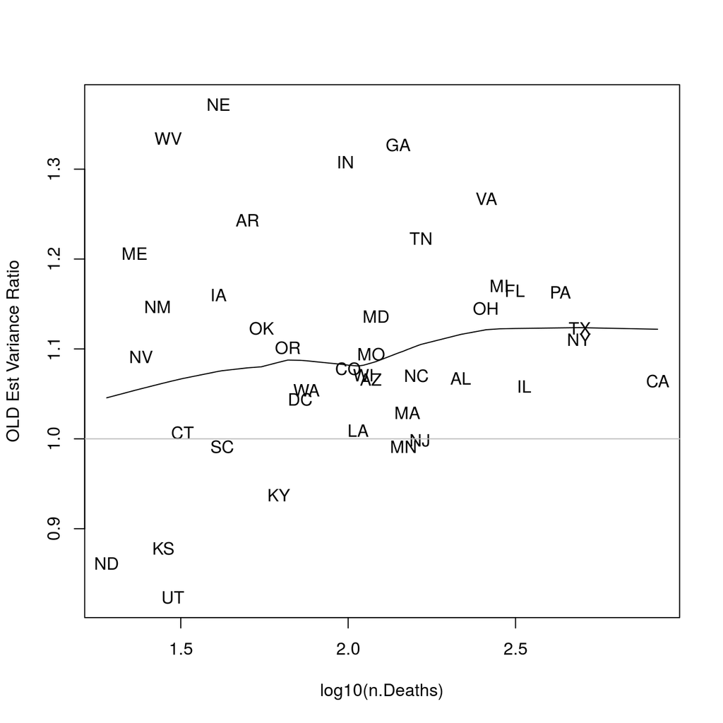

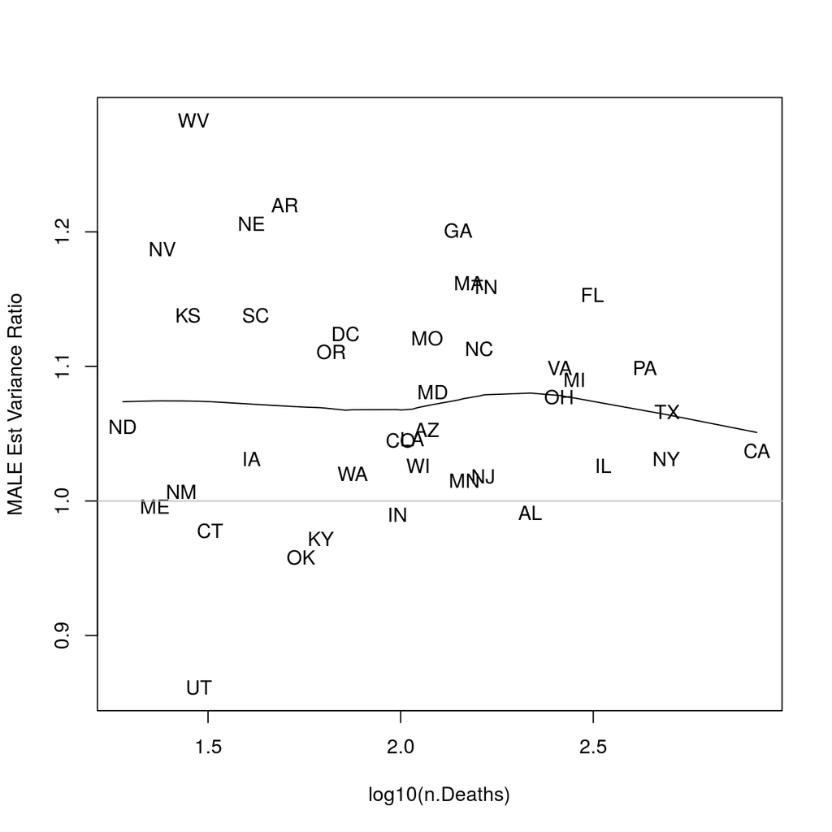

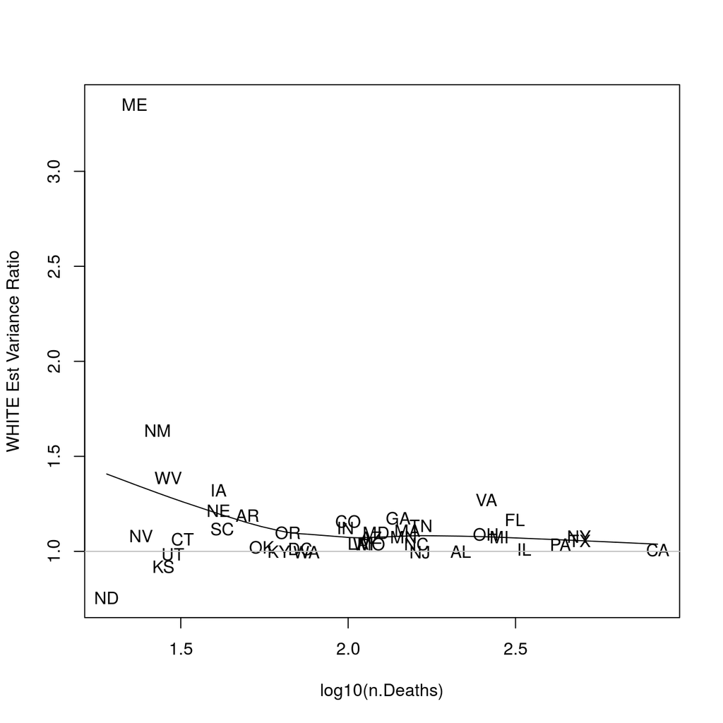

## Christmas Trees

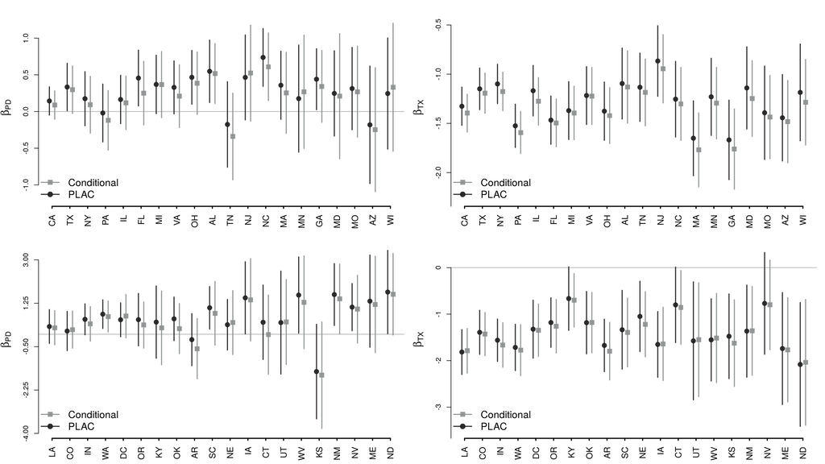

## Maps

Maps are made with a color gradient showing the magnitudes of the hazards ratios for PD and TX.

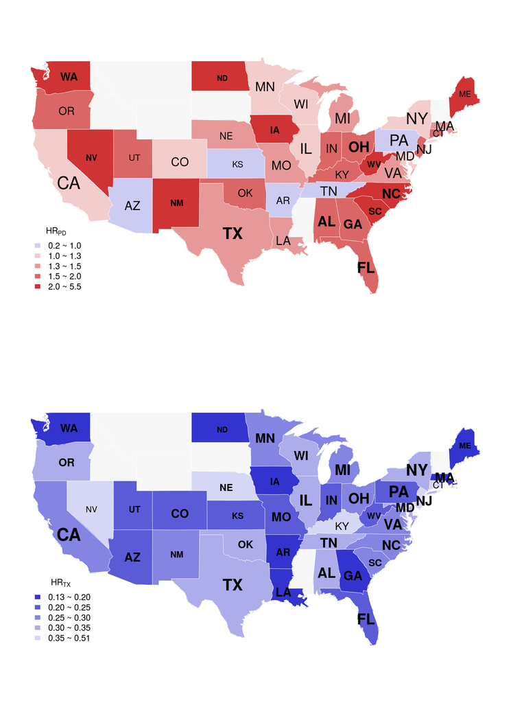

## Selected States

```
##
##
##         LHR      HR      SE      Z         P       LHR      HR      SE      Z         P       RE
## ------  -------  ------  ------  --------  ------  -------  ------  ------  --------  ------  ------
## YOUNG   -0.566   0.568   0.172   -3.294    0.001   -0.556   0.573   0.167   -3.325    0.001   1.055
## OLD     0.760    2.138   0.123   6.167     0.000   0.845    2.328   0.114   7.404     0.000   1.165
## WHITE   0.457    1.579   0.117   3.901     0.000   0.558    1.746   0.108   5.142     0.000   1.166
## MALE    0.287    1.332   0.117   2.448     0.014   0.286    1.331   0.109   2.621     0.009   1.153
## PD      0.251    1.285   0.221   1.134     0.257   0.456    1.578   0.194   2.354     0.019   1.301
## TX      -1.495   0.224   0.124   -12.061   0.000   -1.467   0.231   0.125   -11.742   0.000   0.984
## FL 1040 315 69.7
##
##
##         LHR      HR      SE      Z        P       LHR      HR      SE      Z        P       RE
## ------  -------  ------  ------  -------  ------  -------  ------  ------  -------  ------  ------
## YOUNG   -0.601   0.549   0.233   -2.582   0.010   -0.697   0.498   0.218   -3.201   0.001   1.141
## OLD     0.685    1.985   0.202   3.391    0.001   0.711    2.037   0.175   4.055    0.000   1.327
## WHITE   0.897    2.451   0.187   4.805    0.000   0.917    2.501   0.172   5.323    0.000   1.175
## MALE    0.052    1.054   0.170   0.309    0.757   0.049    1.051   0.155   0.319    0.750   1.201
## PD      0.343    1.409   0.250   1.375    0.169   0.440    1.553   0.212   2.072    0.038   1.380
## TX      -1.761   0.172   0.208   -8.467   0.000   -1.668   0.189   0.206   -8.087   0.000   1.017
## GA 483 141 70.8
##
##
##         LHR      HR      SE      Z        P       LHR      HR      SE      Z        P       RE
## ------  -------  ------  ------  -------  ------  -------  ------  ------  -------  ------  ------
## YOUNG   -0.542   0.581   0.495   -1.095   0.273   -0.549   0.577   0.479   -1.146   0.252   1.068
## OLD     1.246    3.475   0.354   3.518    0.000   1.328    3.775   0.329   4.041    0.000   1.160
## WHITE   0.802    2.231   0.394   2.037    0.042   0.914    2.493   0.343   2.666    0.008   1.321
## MALE    0.857    2.357   0.435   1.969    0.049   0.889    2.433   0.429   2.073    0.038   1.031
## PD      1.389    4.010   0.848   1.638    0.102   1.469    4.344   0.742   1.980    0.048   1.307
## TX      -1.639   0.194   0.402   -4.081   0.000   -1.652   0.192   0.361   -4.581   0.000   1.240
## IA 119 41 65.5
##
##
##         LHR      HR      SE      Z        P       LHR      HR      SE      Z        P       RE
## ------  -------  ------  ------  -------  ------  -------  ------  ------  -------  ------  ------
## YOUNG   -2.023   0.132   0.793   -2.553   0.011   -2.010   0.134   0.751   -2.676   0.007   1.113
## OLD     -0.334   0.716   0.451   -0.741   0.459   -0.377   0.686   0.481   -0.784   0.433   0.878
## WHITE   -0.415   0.661   0.507   -0.818   0.413   -0.314   0.730   0.529   -0.594   0.552   0.919
```

[output cut: 22 more lines]

```
## MALE    0.167    1.182   0.128   1.300    0.194   0.191    1.211   0.122   1.561    0.119   1.099
## PD      0.209    1.233   0.218   0.959    0.338   0.329    1.389   0.184   1.786    0.074   1.406
## TX      -1.222   0.295   0.148   -8.244   0.000   -1.217   0.296   0.150   -8.131   0.000   0.981
## VA 653 259 60.3
##
##
##         LHR      HR      SE      Z        P       LHR      HR      SE      Z        P       RE
## ------  -------  ------  ------  -------  ------  -------  ------  ------  -------  ------  ------
## YOUNG   -1.269   0.281   0.592   -2.141   0.032   -1.486   0.226   0.555   -2.679   0.007   1.141
## OLD     1.175    3.237   0.473   2.486    0.013   1.140    3.126   0.409   2.786    0.005   1.334
## WHITE   0.703    2.019   0.602   1.167    0.243   0.744    2.103   0.511   1.454    0.146   1.385
## MALE    0.198    1.219   0.401   0.493    0.622   0.204    1.226   0.354   0.577    0.564   1.283
## PD      1.288    3.624   0.955   1.348    0.178   1.580    4.853   0.784   2.015    0.044   1.485
## TX      -1.514   0.220   0.489   -3.099   0.002   -1.553   0.212   0.451   -3.446   0.001   1.175
## WV 62 29 53.2
```